# Forecasting # of visitors from Singapore

### CMV

```r
source("source.R")
TS_SE1 <- read.csv("Singapore.csv")
Visitors <- TS_SE1$Singapore
Quarter <- TS_SE1$Month
Season <- max(Quarter)
Period <- TS_SE1$period
t  = Period -1
n <- length(Visitors)
CMV_SI <- Center_Moving_Average(Visitors, Quarter, Season)
cat("# # # # The Centered moving average seasonal index # # # ","\n")
```

```
# # # # The Centered moving average seasonal index # # #
```

```r
print(CMV_SI)
```

```
 [1] 0.7143272 0.6277514 1.1584893 0.9915091 0.9445099 1.0311287 0.6414735 0.6176663 0.7660893
[10] 1.0243304 1.4648784 2.0178465
```

### Forecast by seasonal index

```
### Linear Model ###
Call:
lm(formula = Des_x ~ t)

Residuals:
    Min      1Q  Median      3Q     Max
-6017.7 -1272.9   -44.3  1254.4  7496.9

Coefficients:
            Estimate Std. Error t value Pr(>|t|)
(Intercept) 26049.02     455.89   57.14   <2e-16 ***
t             128.64       8.29   15.52   <2e-16 ***
---
Signif. codes:  0 ‘***’ 0.001 ‘**’ 0.01 ‘*’ 0.05 ‘.’ 0.1 ‘ ’ 1

Residual standard error: 2251 on 94 degrees of freedom
Multiple R-squared:  0.7192,    Adjusted R-squared:  0.7162
F-statistic: 240.8 on 1 and 94 DF,  p-value: < 2.2e-16


    Shapiro-Wilk normality test

data:  Standard_E
W = 0.96927, p-value = 0.02356

run test:[1] 0.02399074
The Outliers[1]  9 28 46 70 81 82 92
influential observations:[1] "no influential observations"
mean_y: 32159.35



deseasonalized data:
 [1] 23583.66 24817.46 28074.43 27597.42 25242.49 24535.05 26142.10 28005.60 21060.38 28995.56
[11] 26632.10 27703.22 27264.93 26550.52 26566.96 24474.38 24755.60 27878.70 29043.37 29898.71
[21] 28902.72 26970.87 29907.91 30713.79 31307.24 31015.53 30342.64 34695.11 32784.69 31325.83
[31] 28878.17 29785.72 28043.17 33919.48 29930.36 30892.30 32758.79 33757.18 32531.35 29391.27
[41] 31222.21 33690.30 31302.26 30008.23 33516.85 26376.68 30696.87 32661.32 32806.43 32694.27
[51] 33795.63 36080.97 34934.57 31756.35 33972.10 33139.79 34065.62 33937.00 33126.76 31779.84
[61] 31225.72 33426.48 33349.78 31028.08 35563.74 34306.31 35922.44 35788.65 35049.77 41232.88
[71] 36299.00 34540.28 33167.47 35781.18 34955.46 36430.67 34415.05 35104.88 35912.88 34828.22
[81] 43837.06 31227.33 37048.25 35531.70 36424.18 32960.97 35982.78 36618.48 35957.95 36024.51
[91] 36569.59 32731.43 40509.45 41017.83 38944.68 39342.05
```

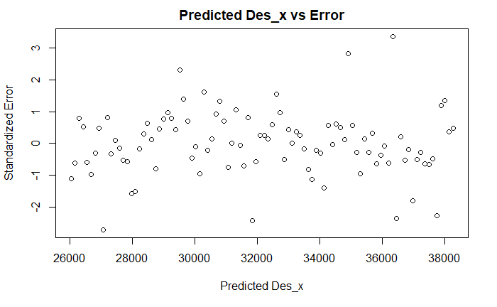

```r
Forecast_Visitors_CMV= Forecast_by_SI(Visitors, Quarter, Season, CMV_SI, t)
```

```r
#cat("# # # # The Forecast_Visitors_y # # # ","\n")
#print(Forecast_Visitors_CMV)
t2 = c(t,n,n+1,n+2,n+3,n+4,n+5,n+6,n+7,n+8,n+9,n+10,n+11)
lines(t,Visitors, col = "blue", main = "Visitorsagainst Period", xlab = "Period", ylab = "Tourists")
lines(t, Visitors, type="o", col = "blue")    #actual
```

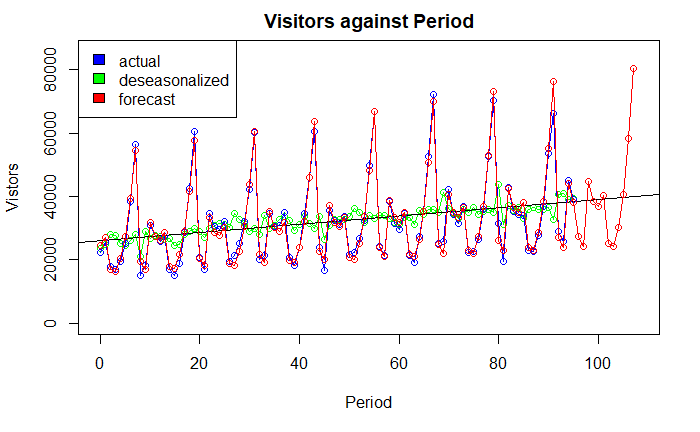

```r
lines(t2,Forecast_Visitors_CMV, type="o", col = "red")  #forecast
legend("topleft", c("actual", "deseasonalized", "forecast"), fill=c("blue","green", "red"))
```

## Smoothing by Linear Regression Model

```r
SLR_SI <- Linear_Regression_Seasonal_Index(Visitors, Quarter, Season)
cat("# # # # The Simple Linear_Regression seasonal index # # # ","\n")
```

```
# # # # The Simple Linear_Regression seasonal index # # #
```

```r
print(SLR_SI)
```

```
 [1] 0.7226949 0.6354943 1.1619297 0.9952488 0.9364848 1.0290398 0.6496689 0.6239400 0.7646471
[10] 1.0183484 1.4674456 1.9950578
```

### Forecast by seasonal index

```
### Linear Model ###
Call:
lm(formula = Des_x ~ t)

Residuals:
    Min      1Q  Median      3Q     Max
-6218.1 -1180.2    73.2  1286.8  7082.3

Coefficients:
             Estimate Std. Error t value Pr(>|t|)
(Intercept) 26010.965    447.801   58.09   <2e-16 ***
t             127.953      8.143   15.71   <2e-16 ***
---
Signif. codes:  0 ‘***’ 0.001 ‘**’ 0.01 ‘*’ 0.05 ‘.’ 0.1 ‘ ’ 1

Residual standard error: 2211 on 94 degrees of freedom
Multiple R-squared:  0.7243,    Adjusted R-squared:  0.7213
F-statistic: 246.9 on 1 and 94 DF,  p-value: < 2.2e-16


    Shapiro-Wilk normality test

data:  Standard_E
W = 0.97061, p-value = 0.02958

run test:[1] 0.06476695
The Outliers[1]  9 28 46 70 81 82 92
influential observations:[1] "no influential observations"
mean_y: 32088.73



deseasonalized data:
 [1] 23785.76 24867.84 27720.27 27319.93 25290.10 24679.18 26096.37 28325.50 20816.53 28642.27
[11] 26553.24 27599.13 27498.58 26604.41 26231.82 24228.29 24802.29 28042.46 28992.56 30240.23
[21] 28568.07 26642.25 29819.36 30598.38 31575.53 31078.49 29959.88 34346.25 32846.53 31509.84
[31] 28827.65 30125.94 27718.47 33506.20 29841.74 30776.22 33039.51 33825.71 32120.98 29095.75
[41] 31281.10 33888.20 31247.50 30351.00 33128.78 26055.31 30605.98 32538.60 33087.56 32760.64
[51] 33369.31 35718.18 35000.46 31942.90 33912.67 33518.33 33671.19 33523.51 33028.68 31660.42
[61] 31493.30 33494.33 32929.08 30716.09 35630.82 34507.83 35859.59 36197.45 34643.94 40730.50
[71] 36191.52 34410.49 33451.69 35853.81 34514.50 36064.36 34479.96 35311.10 35850.05 35226.05
[81] 43329.49 30846.86 36938.55 35398.18 36736.31 33027.88 35528.87 36250.28 36025.77 36236.12
[91] 36505.61 33105.31 40040.41 40518.07 38829.37 39194.22
```

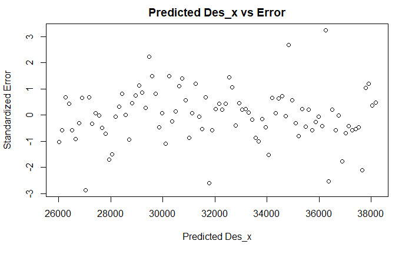

```r
Forecast_Visitors_SLR <- Forecast_by_SI(Visitors, Quarter, Season, SLR_SI, t)
```

```r
cat("# # # # The Forecast_Visitors_y # # # ","\n")
```

```
# # # # The Forecast_Visitors_y # # #
```

```r
print(Forecast_Visitors_SLR)
```

```
  [1] 24358.87 26897.99 17064.77 16468.79 20280.56 27139.73 39296.26 53680.29 19537.76 17261.64
 [11] 31709.63 27288.18 25796.78 28478.01 18062.29 17426.81 21454.63 28703.34 41549.42 56743.57
 [21] 20647.41 18237.40 33493.70 28816.32 27234.69 30058.03 19059.82 18384.82 22628.69 30266.94
 [31] 43802.59 59806.85 21757.06 19213.16 35277.77 30344.45 28672.61 31638.05 20057.34 19342.84
 [41] 23802.76 31830.55 46055.76 62870.13 22866.71 20188.92 37061.83 31872.59 30110.52 33218.08
 [51] 21054.86 20300.86 24976.82 33394.16 48308.92 65933.41 23976.36 21164.68 38845.90 33400.73
 [61] 31548.43 34798.10 22052.39 21258.88 26150.89 34957.76 50562.09 68996.69 25086.01 22140.44
 [71] 40629.97 34928.87 32986.34 36378.12 23049.91 22216.90 27324.95 36521.37 52815.25 72059.97
 [81] 26195.66 23116.20 42414.03 36457.01 34424.25 37958.15 24047.44 23174.92 28499.02 38084.98
 [91] 55068.42 75123.25 27305.31 24091.96 44198.10 37985.15 27675.20 24417.21 44792.79 38494.53
[101] 36341.46 40064.84 25377.47 24452.28 30064.44 40169.79 58072.64 79207.62
```

```r
lines(t, Visitors, type="o", col = "blue")    #actual
lines(t2,Forecast_Visitors_SLR, type="o", col = "red")  #forecast
```

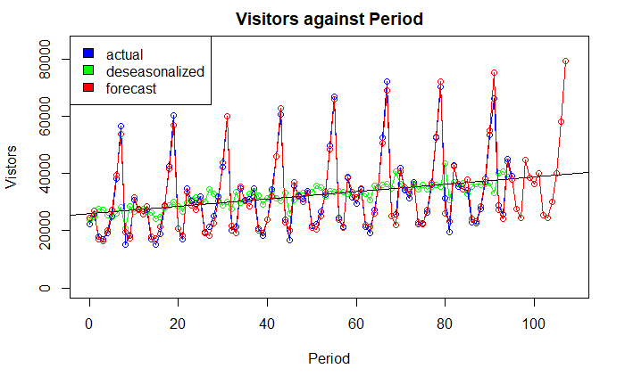

```r
legend("topleft", c("actual", "deseasonalized", "forecast"), fill=c("blue","green", "red"))
```

## Regression model by indicator variables

### The Regression Model

y = beta0 + beta1*t + beta2*Q1 + beta3*Q2 + beta4*Q3 + beta5*Q4 +beta6*Q5 +beta7*Q6 +beta8*Q7 +beta*9Q8 +beta10*Q9 +beta11*Q10 +vbeta12Q*11 +e where t = time in chronological order Qi = indicator variable (0, 1).

### Dummy as Quarter

```r
Dummy_I <- Season - 1    # n-1 indicator variables
Q <- matrix(nrow =n, ncol = Dummy_I)
Dummy_Name <- vector("character", length = Dummy_I)
for(i in 1:Dummy_I){
  Dummy_Name[i] <- paste0("Q", i)
}
colnames(Q) <- Dummy_Name
for(i in 1:n){
  for(j in 1:Dummy_I){
    if(Quarter[i] == j){
      Q[i,j] <- 1
    } else {
      Q[i,j] <- 0
    }
  }
}
```

### build the model

```r
Data.Visitors <- cbind(t, Q)  #t, Q1, Q2, Q3...
linearModelVar1 <- lm(Visitors ~ Data.Visitors)
cat("\n# # # # The regression model # # # ","\n")
```

```
# # # # The regression model # # #
```

```r
print(summary(linearModelVar1))
```

```
Call:
lm(formula = Visitors ~ Data.Visitors)

Residuals:
    Min      1Q  Median      3Q     Max
-4759.7 -1638.0   -71.3  1537.0  5899.1

Coefficients:
                   Estimate Std. Error t value Pr(>|t|)
(Intercept)       58115.747    855.175   67.96   <2e-16 ***
Data.Visitorst      122.406      7.984   15.33   <2e-16 ***
Data.VisitorsQ1  -40575.281   1075.462  -37.73   <2e-16 ***
Data.VisitorsQ2  -43667.936   1075.551  -40.60   <2e-16 ***
Data.VisitorsQ3  -26455.467   1075.699  -24.59   <2e-16 ***
Data.VisitorsQ4  -31986.998   1075.906  -29.73   <2e-16 ***
Data.VisitorsQ5  -33913.410   1076.883  -31.49   <2e-16 ***
Data.VisitorsQ6  -31027.066   1076.499  -28.82   <2e-16 ***
Data.VisitorsQ7  -43006.597   1076.173  -39.96   <2e-16 ***
Data.VisitorsQ8  -43834.252   1075.906  -40.74   <2e-16 ***
Data.VisitorsQ9  -39339.158   1075.699  -36.57   <2e-16 ***
Data.VisitorsQ10 -31266.689   1075.551  -29.07   <2e-16 ***
Data.VisitorsQ11 -16795.969   1075.462  -15.62   <2e-16 ***
---
Signif. codes:  0 ‘***’ 0.001 ‘**’ 0.01 ‘*’ 0.05 ‘.’ 0.1 ‘ ’ 1

Residual standard error: 2151 on 83 degrees of freedom
Multiple R-squared:  0.9763,    Adjusted R-squared:  0.9729
F-statistic: 285.2 on 12 and 83 DF,  p-value: < 2.2e-16
```

```r
cat(" ","\n")
```

```r
ANOVA_T_lm <- anova(linearModelVar1)
cat("# # # # The ANOVA Table # # # ","\n")
```

```
# # # # The ANOVA Table # # #
```

```r
print(ANOVA_T_lm)
```

```
Analysis of Variance Table

Response: Visitors
              Df     Sum Sq    Mean Sq F value    Pr(>F)
Data.Visitors 12 1.5830e+10 1319167172  285.15 < 2.2e-16 ***
Residuals     83 3.8398e+08    4626218
---
Signif. codes:  0 ‘***’ 0.001 ‘**’ 0.01 ‘*’ 0.05 ‘.’ 0.1 ‘ ’ 1
```

```r
#residual analysis
SE_1 <- standarized_errors_MR(Visitors, Data.Visitors)[,1]
h_1 <- standarized_errors_MR(Visitors, Data.Visitors)[,2]
D_1 <- standarized_errors_MR(Visitors, Data.Visitors)[,3]
print(shapiro.test(SE_1) )          # normality
```

```
    Shapiro-Wilk normality test

data:  SE_1
W = 0.99295, p-value = 0.8984
```

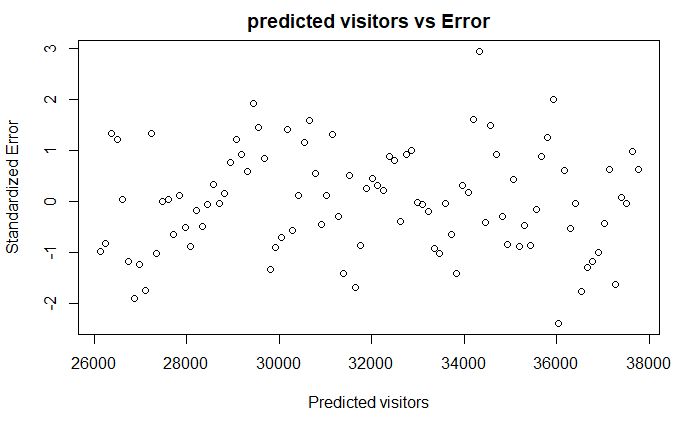

```r
b0<- coef(linearModelVar1)[1]             # Homoscedasticity & Heteroscedasticity
b1 <- coef(linearModelVar1)[2]
b2 <- coef(linearModelVar1)[3]
b3 <- coef(linearModelVar1)[4]
b4 <- coef(linearModelVar1)[5]
b5 <- coef(linearModelVar1)[6]
b6 <- coef(linearModelVar1)[7]
b7 <- coef(linearModelVar1)[8]
b8 <- coef(linearModelVar1)[9]
b9 <- coef(linearModelVar1)[10]
b10 <- coef(linearModelVar1)[11]
b11 <- coef(linearModelVar1)[12]
b12 <- coef(linearModelVar1)[13]
yhat <- vector("double", length = n)
for(i in 1:n) {
       yhat <- b0 + b1 *t + b2 *Q[i,1] + b3 *Q[i,2] + b4 *Q[i,3]+ b5 *Q[i,4]+ b6 *Q[i,5]+ b7 *Q[i,6]+ b8 *Q[i,7]+ b9 *Q[i,8]+ b10 *Q[i,9]+ b11 *Q[i,10]+ b12 *Q[i,11]
}
plot(x = yhat, y = SE_1, xlab = "Predicted visitors", ylab = "Standardized Error", main = "predicted visitors vs Error")
```

```r
cat("\nRun_Test:\n")
```

```
Run_Test:
```

```r
print(Run_Test(SE_1))              #errors are independent
```

```
[1] 0.06476695
```

```r
cat("\nThe Outliers\n")
```

```
The Outliers
```

```r
Outliers <- abs(SE_1) > 2
if(sum(Outliers)!=0){
    print(which(Outliers))
}else{
  print("no outliers")
}
```

```
[1] 68 82
```

```r
cat("\ninfluential observations:\n")
```

```
influential observations:
```

```r
k <- dim(Data.Visitors)[2]
Inf_Obs <- h_1 > 3*(k+1)/n
if(sum(Inf_Obs)!=0){
    print(which(Inf_Obs))
}else{
  print("no influential observations")
}
```

```
[1] "no influential observations"
```

```r
#assesment
cat("\nmean_y:",mean(Visitors),"\n")
```

```
mean_y: 32107.61
```

*Residual analysis:*  
1.normality test  
H0: Errors are normally distributed.  
H1: Errors are not normally distributed.  
Since pvalue = 0.8984 > 0.05, we do not reject H0.

2..Homoscedasticity & Heteroscedasticity  
H0: The variance of e is the same for all values of x.  
H1: The variance of e is not the same for all values of x.  
According to the plot, there is no sign of heteroscedasticity.

3.Dependence of the Error Variable  
H0 : Randomness exists.  
H1 : Randomness does not exist.  
Since pvalue = 0.065 > 0.05, we do not reject H0.

*Assessment*  
The standard error of estimate (2151) is samll compared to mean_y (32107.61). We can conclude that the model fit the data well.

The F-test of ANOVA: H0: beta1 = beta2 = … = beta11 = 0 H1: At least one betai is not equal to zero. ` since p-value < 2.2e-16 < 0.05, there is sufficient evidence to reject the null hypothesis. At least one of the betai is not equal to zero. Thus, at least one independent variable is related to y. This regression model is valid.

Testing of the Coefficients H0: betai = 0 H1: betai != 0 ` Since all the pvalue are < 0.05, there is overwhelming evidence to infer that t and all the Qi affects the # of visitors.

### Forecast

```r
NoB <- Dummy_I + 2  #b0 ,b1(t), b2(Q1), b3(Q2), b4(Q3)...
bi <- vector("double", length = NoB)
for(i in 1:NoB){
  bi[i] <- coef(linearModelVar1)[i]  #bi[1]:intercept, bi[2]: coefficient of t
}
b0 <- vector("double", length = n)
for(j in 1:n) {
    b0[j] <- 1
}
Data.Visitors_0 <- cbind(b0, Data.Visitors) # matrix[n*NoB]: each bi for all the n samples
y_Dummy <- c(Data.Visitors_0 %*% bi)     # bi[NoB*1]: 1 (*b0), t (*b1), 1or0 (*b2), 1or0 (*b3)...  #only 24 periods
#the next 12 months for
Q1 = bi[1] + bi[2]*108 + bi[3]
Q2 = bi[1] + bi[2]*109 + bi[4]
Q3 = bi[1] + bi[2]*110 + bi[5]
Q4 = bi[1] + bi[2]*111 + bi[6]
Q5 = bi[1] + bi[2]*112 + bi[7]
Q6 = bi[1] + bi[2]*113 + bi[8]
Q7 = bi[1] + bi[2]*114 + bi[9]
Q8 = bi[1] + bi[2]*115 + bi[10]
Q9 = bi[1] + bi[2]*116 + bi[11]
Q10 = bi[1] + bi[2]*117 + bi[12]
Q11 = bi[1] + bi[2]*118 + bi[13]
Q12 =  bi[1] + bi[2]*119   ###
y_Dummy = c(y_Dummy,Q1,Q2,Q3,Q4,Q5,Q6,Q7,Q8,Q9,Q10,Q11,Q12)  #28 periods total
cat("# # # # The Forecast_Visitors_y# # # ","\n")
```

```
# # # # The Forecast_Visitors_y# # #
```

```r
print(y_Dummy)
```

```
  [1] 24202.34 27211.09 15353.96 14648.71 19266.21 27461.09 42054.21 58972.59 18519.71 15549.46
 [11] 32884.34 27475.21 25671.20 28679.95 16822.83 16117.58 20735.08 28929.95 43523.08 60441.45
 [21] 19988.58 17018.33 34353.20 28944.08 27140.07 30148.82 18291.70 17586.45 22203.95 30398.82
 [31] 44991.95 61910.32 21457.45 18487.20 35822.07 30412.95 28608.94 31617.69 19760.57 19055.32
 [41] 23672.82 31867.69 46460.82 63379.19 22926.32 19956.07 37290.94 31881.82 30077.81 33086.56
 [51] 21229.43 20524.18 25141.68 33336.56 47929.68 64848.06 24395.18 21424.93 38759.81 33350.68
 [61] 31546.68 34555.43 22698.30 21993.05 26610.55 34805.43 49398.55 66316.93 25864.05 22893.80
 [71] 40228.68 34819.55 33015.55 36024.30 24167.17 23461.92 28079.42 36274.30 50867.42 67785.80
 [81] 27332.92 24362.67 41697.55 36288.42 34484.41 37493.16 25636.04 24930.79 29548.29 37743.16
 [91] 52336.29 69254.66 28801.79 25831.54 43166.41 37757.29 30760.28 27790.03 45124.90 39715.78
[101] 37911.77 40920.52 29063.40 28358.15 32975.65 41170.52 55763.65 72682.02
```

```r
write.csv(y_Dummy,"../../temp.csv")
t2 = c(t,n,n+1,n+2,n+3,n+4,n+5,n+6,n+7,n+8,n+9,n+10,n+11)
plot(t,Visitors, col = "blue", main = "Visitors against Period", xlab = "Period", ylab = "Vistitors", xlim=range(t2, t2+1), ylim=range(y_Dummy,0))
lines(t, Visitors, type="o", col = "blue")    #actual
```

```r
lines(t2,y_Dummy, type="o", col = "red")  #forecast
abline(lm(Visitors ~ t))
```

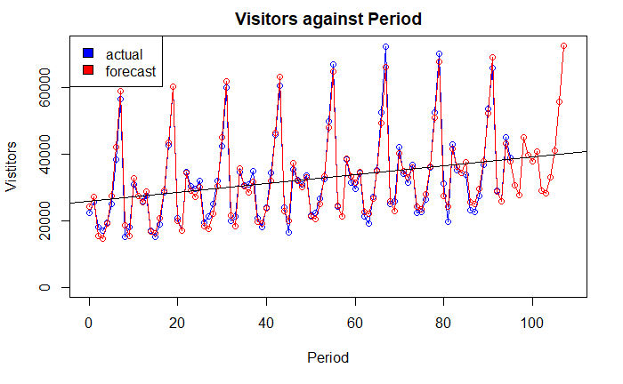

```r
legend("topleft", c("actual", "forecast"), fill=c("blue","red"))
```

The # of visitors forecast for the next 12 months are 30760.28, 27790.03, 45124.90, 39715.78 , 37911.77, 40920.52, 29063.40, 28358.15, 32975.65, 41170.52, 55763.65, and 72682.02.

## Error Metrics

```r
Dummy_MAD <- Mean_Absolute_Deviation(Visitors, y_Dummy, 1)
Dummy_MSE <- Mean_Square_Error(Visitors, y_Dummy, 1)
Dummy_MAPE <- Mean_Absolute_Percentage_Error(Visitors, y_Dummy, 1)
Error_M <- matrix(nrow = 3, ncol = 1)
colnames(Error_M) = c("Dummy")
rownames(Error_M) = c("MAD", "MSE", "MAPE")
Error_M[1,1] <- Dummy_MAD
Error_M[2,1] <- Dummy_MSE
Error_M[3,1] <- Dummy_MAPE
cat("\n# # # # Error Metrix # # # ","\n")
print(Error_M)
```

[output not shown]

## Conclusion:

By Regression model by indicator variables, we forecast that the number of visitors from Singapore for the next 12 months will be 30760.28, 27790.03, 45124.90, 39715.78 ,37911.77, 40920.52, 29063.40, 28358.15, 32975.65, 41170.52, 55763.65, and 72682.02. respectively.